# Proving Central Limit Theorem, Law of Large Numbers

Convergence of sample mean to population mean as n goes to infinity

```r
# generate uniform samples where P(X=1)=P(X=-1)=1/2
generate.uniform.samples <- function(n, col) {
  #create empty matrix with n datapoints and ncol datasets
  #each column represents a different dataset
  datasets <- matrix(data = NA, nrow = n, ncol = col)
  #make the datasets into a dataframe
  datasets <- as.data.frame(datasets)
  # randomly sample values between 0 and 1 but set all values above
  # 0.5 as -1 and all values less than or equal to 0.5 as 1
  for (i in 1:col){
    samples <- runif(n, min=0, max=1)
    samples <- replace(samples, samples < 0.5, -1)
    samples <- replace(samples, samples >= 0.5, 1)
    datasets[i] = samples
  }
  # return datasets
  return(datasets)
}
```

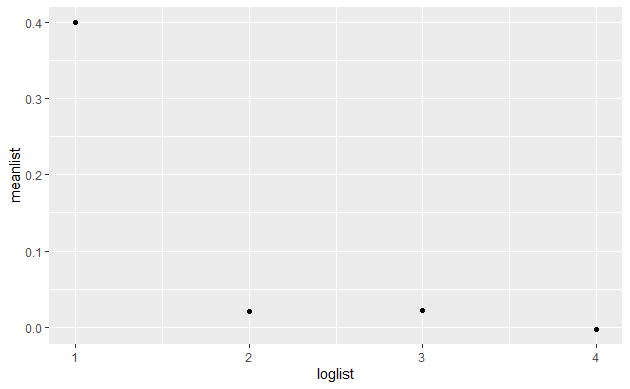

```r
#load tidyverse library
library(tidyverse)
# create list of 10, 100, 1000, 10000 and take log of values
loglist <- c(10, 100, 1000, 10000)
loglist <- as.data.frame(loglist)
loglist <- log10(loglist)
mu = 0
# the population mean of our samples is 0 since X=1 and X=-1 have probabilities
# 1/2, thus the expectation is 0
# generate samples for # of data points being 10, 100, 1000, 10000
points10 <- generate.uniform.samples(10, 1)
points100 <- generate.uniform.samples(100, 1)
points1000 <- generate.uniform.samples(1000, 1)
points10000 <- generate.uniform.samples(10000, 1)
# calculate sample mean of the points
mean10 <- mean(points10[,1])
mean100 <- mean(points100[,1])
mean1000 <- mean(points1000[,1])
mean10000 <- mean(points10000[,1])
# create dataframe to plot sample means
meanlist <- c(mean10, mean100, mean1000, mean10000)
meanlist <- as.data.frame(meanlist)
tograph <- as.data.frame(meanlist)
tograph[2] <- loglist
# plot values of sample means against
ggplot(tograph, aes(x=loglist, y=meanlist))+geom_point()
```

This plot showed us that the deviation between sample mean and population mean converges to 0 as n goes to infinity

Law of Large Numbers

```r
# given a number of data points and an epsilon, find differences (between sample mean and population mean) and only get those that are greater than epsilon
diff.less.eps = function(n, epsilon){
  samples <- generate.uniform.samples(n, 10000)
  count <- 0
  for (i in 1:10000){
    avg <- mean(samples[,i])
    if (avg > epsilon) {
      count = count + 1
    }
  }
  return (1/10000 * count)
}
# create data frame where first column is differences for datasets with 10, 100, 1000 and 10000 data points and second column is the column with log of n datapoints.
diff.for.n = function(epsilon){
  difffor10 <- diff.less.eps(10, epsilon)
  difffor100 <- diff.less.eps(100, epsilon)
  difffor1000 <- diff.less.eps(1000, epsilon)
  difffor10000 <- diff.less.eps(10000, epsilon)
  difflist <- c(difffor10, difffor100, difffor1000, difffor10000)
  difflist <- as.data.frame(difflist)
  tograph <- as.data.frame(difflist)
  loglist <- c(10, 100, 1000, 10000)
  loglist <- as.data.frame(loglist)
  loglist <- log10(loglist)
  tograph[2] <- loglist
  return(tograph)
}
# get dataframes for each epsilon of 0.5, 0.1 and 0.05
tograph0.5 <- diff.for.n(0.5)
tograph0.1 <- diff.for.n(0.1)
tograph0.05 <- diff.for.n(0.05)
```

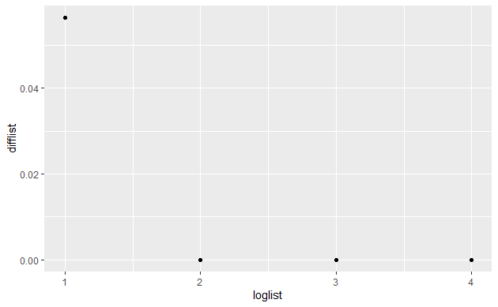

```r
#plot dataframes
ggplot(tograph0.5, aes(x=loglist, y=difflist))+geom_point()
```

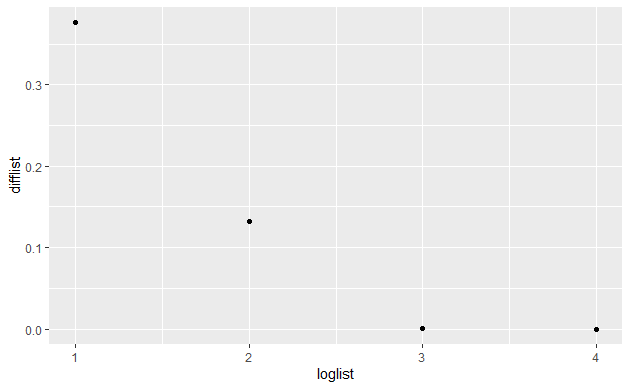

```r
ggplot(tograph0.1, aes(x=loglist, y=difflist))+geom_point()
```

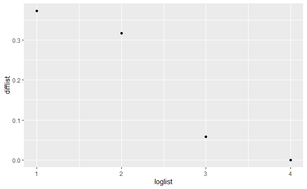

```r
ggplot(tograph0.05, aes(x=loglist, y=difflist))+geom_point()
```

This shows the law of large numbers. As the number of datapoints grows, the the mean differences between sample mean and population mean get smaller. This is excessively noticable as the epsilon gets smaller. We notice a trend of “as n gets larger, the mean differences decrease”

Central Limit Theorem

```r
# create samples for n datapoints with col datasets
generate.uniform.samples <- function(n, col) {
  dataset <- matrix(data = NA, nrow = n, ncol = col)
  dataset <- as.data.frame(dataset)
  for (i in 1:col){
    samples <- runif(n, min=0, max=1)
    samples <- replace(samples, samples < 0.5, -1)
    samples <- replace(samples, samples >= 0.5, 1)
    dataset[i] = samples
  }
  return(dataset)
}
# get samples for 10 datapoints in 10000 datasets
samp10 <- generate.uniform.samples(10, 10000)
# get samples for 1000 datapoints in 10000 datasets
samp1000 <- generate.uniform.samples(1000, 10000)
# get samples for 10000 datapoints in 10000 datasets
samp10000 <- generate.uniform.samples(10000, 10000)
```

```r
# get the average of each dataset in the inputted dataframe
avg <- function(x){
  averg = matrix(data=NA, nrow=1, ncol=10000)
  for (i in 1:10000){
    avg <- mean(x[,i])
    averg[i] <- avg
  }
  return(averg)
}
# get average of dataframe with 10000 datasets with 10 datapoints each
samp10 <- avg(samp10)
# get average of dataframe with 10000 datasets with 1000 datapoints each
samp1000 <- avg(samp1000)
# get average of dataframe with 10000 datasets with 10000 datapoints each
samp10000 <- avg(samp10000)
```

```r
# multiply average of dataframe with the square root of the number of data points in each dataset
samp10 <- samp10*sqrt(10)
samp1000 <- samp1000*sqrt(1000)
samp10000 <- samp10000*sqrt(10000)
```

```r
# create data frame for each calculation
samp10 <- data.frame(col = c(t(samp10)), stringsAsFactors = FALSE)
samp1000 <- data.frame(col = c(t(samp1000)), stringsAsFactors = FALSE)
samp10000 <- data.frame(col = c(t(samp10000)), stringsAsFactors = FALSE)
```

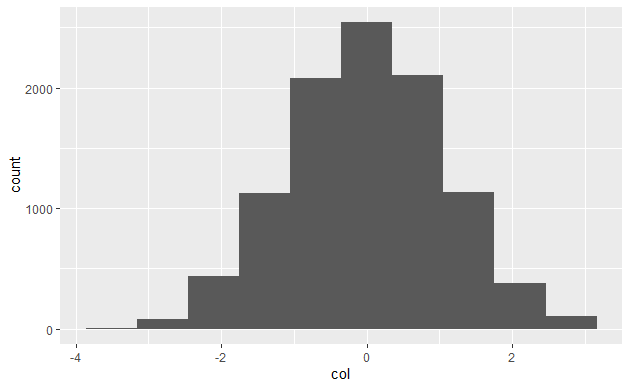

```r
#plot each calculation as histograms
ggplot(samp10, aes(x=col)) + geom_histogram(bins = 10)
```

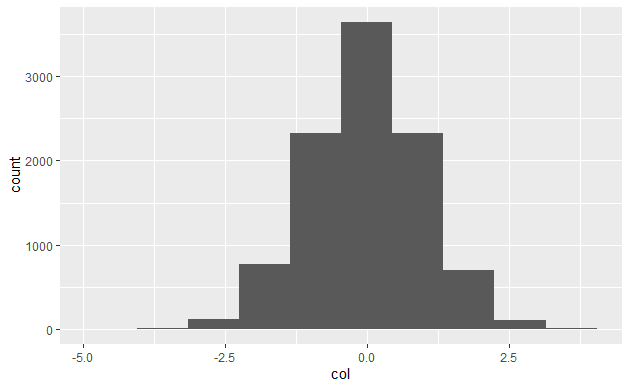

```r
ggplot(samp1000, aes(x=col)) + geom_histogram(bins = 10)
```

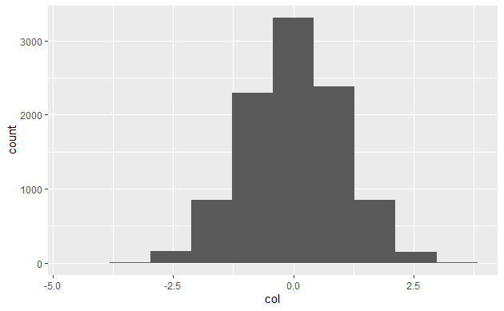

```r
ggplot(samp10000, aes(x=col)) + geom_histogram(bins = 10)
```

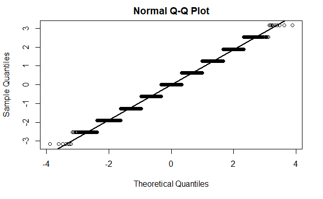

```r
# plot qqplots to see if they follow normality
qqnorm(samp10[,1])
qqline(samp10, lwd=2)
```

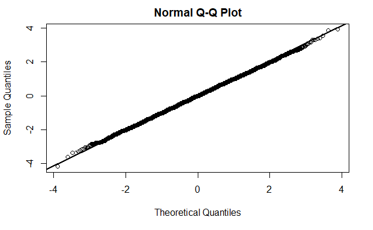

```r
qqnorm(samp1000[,1])
qqline(samp1000, lwd=2)
```

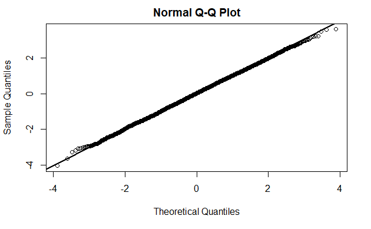

```r
qqnorm(samp10000[,1])
qqline(samp10000, lwd=2)
```

This demonstrates the central limit theorem. as the data is generated from a uniform space. But by subtracting population mean, dividing by population variance (1) and multiplying by square root of the number of datapoints in each dataset, we see that we achieve normality.

```r
# generate 10000 independent random variables
Y <- rnorm(10000, 0, 1);
```

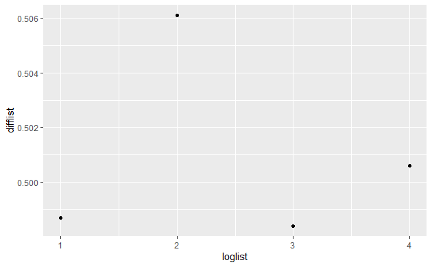

```r
# given n # of datapoints and an epsilon
diff.less.eps = function(n, epsilon){
  # generate 10000 datasets with n datapoints
  samples <- generate.uniform.samples(n, 10000)
  count <- 0
  # for each dataset calculate the mean, multiply it with square root of
  # number n datapoints and subtract the ith random variable of the Y dataframe
  # if the difference is greater than epsilon add 1 to the count variable
  for (i in 1:10000){
    avg <- mean(samples[,i])
    avg <- avg*sqrt(n) - Y[i]
    if (avg > epsilon) {
      count = count + 1
    }
  }
  # divide the count by 10000 and return the value
  return (count/10000)
}
# given epsilon get the differences for 10, 100, 1000, 10000 datapoints in 10000 datasets for each epsilon and return dataframe with differences for given epsilon in first column and log10 of number of datapoints in second column
diff.for.n = function(epsilon){
  difffor10 <- diff.less.eps(10, epsilon)
  difffor100 <- diff.less.eps(100, epsilon)
  difffor1000 <- diff.less.eps(1000, epsilon)
  difffor10000 <- diff.less.eps(10000, epsilon)
  difflist <- c(difffor10, difffor100, difffor1000, difffor10000)
  difflist <- as.data.frame(difflist)
  tograph <- as.data.frame(difflist)
  loglist <- c(10, 100, 1000, 10000)
  loglist <- as.data.frame(loglist)
  loglist <- log10(loglist)
  tograph[2] <- loglist
  return(tograph)
}
#plot the scatterplot graph for diff.for.n of epsilon of 0.001
tograph <- diff.for.n(0.001)
ggplot(tograph, aes(x=loglist, y=difflist)) + geom_point()
```